# Sentiment Analysis on News Sources Regarding Electric Vehicles

Hamza Khan

2023-11-01

Libraries

```r
library(tidytext) # for sentiment analysis
library(tidyverse) # for using read_csv, pipe, filter, ggplot2 and more
```

Reading data file

```r
setwd("C:/Users/Hamza/Desktop/FA2023/LING 460/sentiment-analysis-ev") # setting the working directory
data <- read_csv("ling_460_project_data.csv") # reading the data file
data1 <- data[, c(-1, -5, -6)] # removing unnecessary columns
```

Unnesting tokens

```r
data_unnested <- data1 %>% # creating a data frame named data_unnested from data1
  unnest_tokens(word, text_article) %>%  # unnesting tokens
  anti_join(stop_words) # removing stop words
```

BING Sentiment and recoding positive as 1, negative as 0

```r
data_bing <- data_unnested %>% # creating a data frame named data_bing from data_unnested
  inner_join(get_sentiments("bing")) # using inner_join to match sentiments from the bing lexicon
data_bing$score <- ifelse(data_bing$sentiment == "positive", 1, 0) # creating a new variable in the data frame which is the score variable regrades
```

Summarizing data by source_article, political_lean

```r
data_bing_source <- data_bing %>% # creating a new data frame from data_bing
  group_by(source_article, political_lean) %>% # Grouping by source_article and bringing in political_lean variable
  summarize(avg = mean(score)) # calculating the average for each source_article

data_bing_source <- arrange(data_bing_source, desc(avg)) # sorting the data frame descending by average

data_bing_lean <- data_bing %>% # creating a new data frame from data_bing
  group_by(political_lean) %>% # Grouping by the political_lean variable
  summarize(avg = mean(score)) # calculating the average for each source_article

data_bing_lean <- arrange(data_bing_lean, desc(avg)) # sorting the data frame descending by average
```

Graphing data_bing_source and data_bing_lean This revealed that left news sources have higher sentiment than news sources without a lean, and then right leaning news sources. Although it varies for sources in the middle and right.

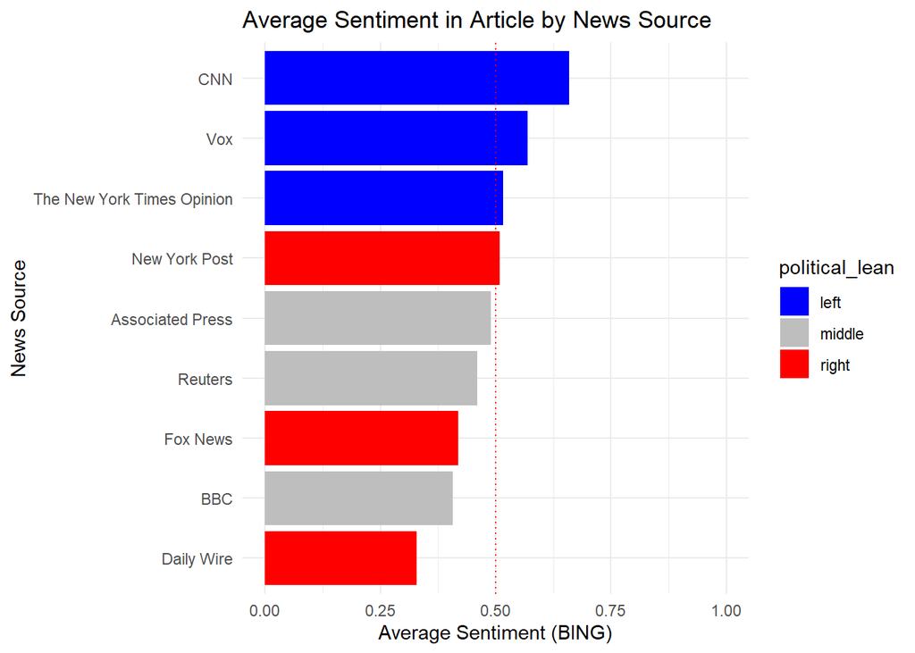

```r
# creating bar graph for data_bing_source with legend and sorted by avg
ggplot(data = data_bing_source, aes(reorder(source_article, avg), avg, fill = political_lean)) +
  geom_col() + # bar chart
  coord_flip() + # making it horizontal for legibility
  ggtitle("Average Sentiment in Article by News Source") + # title
  theme_minimal() + # theme
  ylab("Average Sentiment (BING)") + # x-axis label (coord_flip is why this is x-axis)
  xlab("News Source") + # y-axis label (coord_flip is why this is y-axis)
  scale_y_continuous(limits = c(0,1)) + # setting scales for x-axis (coord flipped)
  geom_hline(yintercept = .5, linetype='dotted', col = 'red') + # creating a vertical line at the .5 mark (coord flipped)
  scale_fill_discrete(name = "Political Lean") + # labeling legend
  scale_fill_manual(values=c("blue", "gray", "red")) # setting colors
```

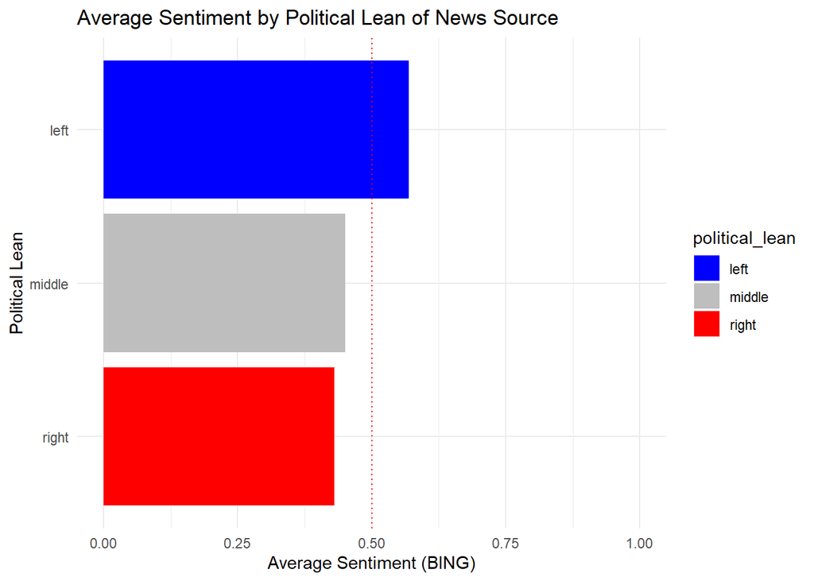

```r
# creating bar graph for data_bing_lean with legend and sorted by avg
ggplot(data = data_bing_lean, aes(reorder(political_lean, avg), avg, fill = political_lean)) +
  geom_col() + # bar chart
  coord_flip() + # making it horizontal for legibility
  ggtitle("Average Sentiment by Political Lean of News Source") + # title
  theme_minimal() + # theme
  ylab("Average Sentiment (BING)") + # x-axis label (coord_flip is why this is x-axis)
  xlab("Political Lean") + # y-axis label (coord_flip is why this is y-axis)
  scale_y_continuous(limits = c(0,1)) + # setting scales for x-axis (coord flipped)
  geom_hline(yintercept = .5, linetype='dotted', col = 'red') + # creating a vertical line at the .5 mark (coord flipped)
  scale_fill_discrete(name = "Political Lean") + # labeling legend
  scale_fill_manual(values=c("blue", "gray", "red")) # setting colors
```

Three separate dataframes, one for each political lean

```r
left <- filter(data_bing, political_lean == "left") # filtering data_bing where political_lean is left
middle <- filter(data_bing, political_lean == "middle") # filtering data_bing where political_lean is middle
right <- filter(data_bing, political_lean == "right") # filtering data_bing where political_lean is right
```

T-test (welch due to difference in sample sizes) - H0: There are no differences in sentiment between news sources of different political leans - HA: There are differences in sentiment between news sources of different political leans

- Left and Right: lowest p-value indicating that different political leans have differences in sentiment
- Left and Middle: low p-value indicating that different political leans have differences in sentiment
- Middle and Right: high p-value (above 0.05) indicating that different political leans don’t have differences in sentiment

```r
t.test(left$score, right$score) # calculating t-test for the left and right columns
```

```
##
##  Welch Two Sample t-test
##
## data:  left$score and right$score
## t = 5.9339, df = 1339.9, p-value = 3.761e-09
## alternative hypothesis: true difference in means is not equal to 0
## 95 percent confidence interval:
##  0.09306264 0.18498464
## sample estimates:
## mean of x mean of y
## 0.5697241 0.4307004
```

```r
t.test(left$score, middle$score) # calculating t-test for the left and middle columns
```

```
##
##  Welch Two Sample t-test
##
## data:  left$score and middle$score
## t = 5.2103, df = 1480.1, p-value = 2.152e-07
## alternative hypothesis: true difference in means is not equal to 0
## 95 percent confidence interval:
##  0.07439244 0.16422928
## sample estimates:
## mean of x mean of y
## 0.5697241 0.4504132
```

```r
t.test(middle$score, right$score) # calculating t-test for the middle and right columns
```

```
##
##  Welch Two Sample t-test
##
## data:  middle$score and right$score
## t = 0.74116, df = 1387.4, p-value = 0.4587
## alternative hypothesis: true difference in means is not equal to 0
## 95 percent confidence interval:
##  -0.03246198  0.07188754
## sample estimates:
## mean of x mean of y
## 0.4504132 0.4307004
```

Creating dummy variable in data_bing_source to use in making glm I made three dummy variables instead of two for the glm, otherwise I would have done two.

```r
data_bing_source$left <- ifelse(data_bing_source$political_lean == "left", 1, 0) # creating a column in the data_bing_source data frame named left that is one if the political_lean is left and 0 otherwise
data_bing_source$right <- ifelse(data_bing_source$political_lean == "right", 1, 0) # creating a column in the data_bing_source data frame named right that is one if the political_lean is right and 0 otherwise
data_bing_source$middle <- ifelse(data_bing_source$political_lean == "middle", 1, 0) # creating a column in the data_bing_source data frame named middle that is one if the political_lean is middle and 0 otherwise
```

```r
summary(glm(left~avg, data = data_bing_source)) # low p-values # looking at the summary for the logistic regression between left and avg variables
```

```
##
## Call:
## glm(formula = left ~ avg, data = data_bing_source)
##
## Deviance Residuals:
##      Min        1Q    Median        3Q       Max
## -0.42655  -0.23963  -0.03156   0.27579   0.54234
##
## Coefficients:
##             Estimate Std. Error t value Pr(>|t|)
## (Intercept)  -1.5661     0.6287  -2.491   0.0415 *
## avg           3.9215     1.2757   3.074   0.0180 *
## ---
## Signif. codes:  0 '***' 0.001 '**' 0.01 '*' 0.05 '.' 0.1 ' ' 1
##
## (Dispersion parameter for gaussian family taken to be 0.1215834)
##
##     Null deviance: 2.00000  on 8  degrees of freedom
## Residual deviance: 0.85108  on 7  degrees of freedom
## AIC: 10.315
##
## Number of Fisher Scoring iterations: 2
```

```r
summary(glm(right~avg, data = data_bing_source)) # not good # looking at the summary for the logistic regression between right and avg variables
```

```
##
## Call:
## glm(formula = right ~ avg, data = data_bing_source)
##
## Deviance Residuals:
##     Min       1Q   Median       3Q      Max
## -0.5366  -0.3194  -0.1067   0.2563   0.7295
##
## Coefficients:
##             Estimate Std. Error t value Pr(>|t|)
## (Intercept)   1.6131     0.8287   1.947   0.0926 .
## avg          -2.6422     1.6814  -1.571   0.1601
## ---
## Signif. codes:  0 '***' 0.001 '**' 0.01 '*' 0.05 '.' 0.1 ' ' 1
##
## (Dispersion parameter for gaussian family taken to be 0.2112056)
##
##     Null deviance: 2.0000  on 8  degrees of freedom
## Residual deviance: 1.4784  on 7  degrees of freedom
## AIC: 15.285
##
## Number of Fisher Scoring iterations: 2
```

```r
summary(glm(middle~avg, data = data_bing_source)) # even worse # looking at the summary for the logistic regression between middle and avg variables
```

```
##
## Call:
## glm(formula = middle ~ avg, data = data_bing_source)
##
## Deviance Residuals:
##     Min       1Q   Median       3Q      Max
## -0.5321  -0.3029  -0.2236   0.5682   0.6734
##
## Coefficients:
##             Estimate Std. Error t value Pr(>|t|)
## (Intercept)   0.9530     0.9339   1.020    0.341
## avg          -1.2793     1.8949  -0.675    0.521
##
## (Dispersion parameter for gaussian family taken to be 0.2682459)
##
##     Null deviance: 2.0000  on 8  degrees of freedom
## Residual deviance: 1.8777  on 7  degrees of freedom
## AIC: 17.436
##
## Number of Fisher Scoring iterations: 2
```

## ## Going to do the same thing again with the AFINN lexicon ##

AFINN sentiment

```r
data_afinn <- data_unnested %>%  # creating a data frame named data_afinn from data_unnested
  inner_join(get_sentiments("afinn")) # using inner_join to match sentiments from the afinn lexicon
```

Summarizing data from afinn sentiment

```r
data_afinn_source <- data_afinn %>% # creating a new data frame from data_afinn
  group_by(source_article, political_lean) %>% # Grouping by source_article and bringing in political_lean variable
  summarize(avg = mean(value)) # calculating the average for each source_article

data_afinn_source <- arrange(data_afinn_source, desc(avg)) # sorting the data frame descending by average

data_afinn_lean <- data_afinn %>% # creating a new data frame from data_afinn
  group_by(political_lean) %>% # Grouping by the political_lean variable
  summarize(avg = mean(value)) # calculating the average for each source_article

data_afinn_lean <- arrange(data_afinn_lean, desc(avg)) # sorting the data frame descending by average
```

Creating bar graphs

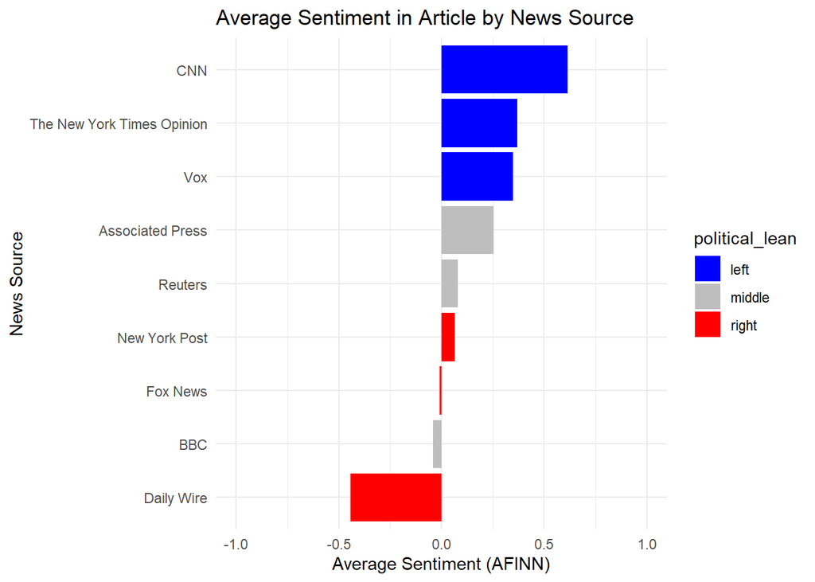

```r
# creating bar graph for data_afinn_source with legend and sorted by avg
ggplot(data = data_afinn_source, aes(reorder(source_article, avg), avg, fill = political_lean)) +
  geom_col() + # bar chart
  coord_flip() + # making it horizontal for legibility
  ggtitle("Average Sentiment in Article by News Source") + # title
  theme_minimal() + # theme
  ylab("Average Sentiment (AFINN)") + # x-axis label (coord_flip is why this is x-axis)
  xlab("News Source") + # y-axis label (coord_flip is why this is y-axis)
  scale_y_continuous(limits = c(-1,1)) + # setting scales for x-axis (coord flipped)
  scale_fill_discrete(name = "Political Lean") + # renaming legend
  scale_fill_manual(values=c("blue", "gray", "red")) # setting colors
```

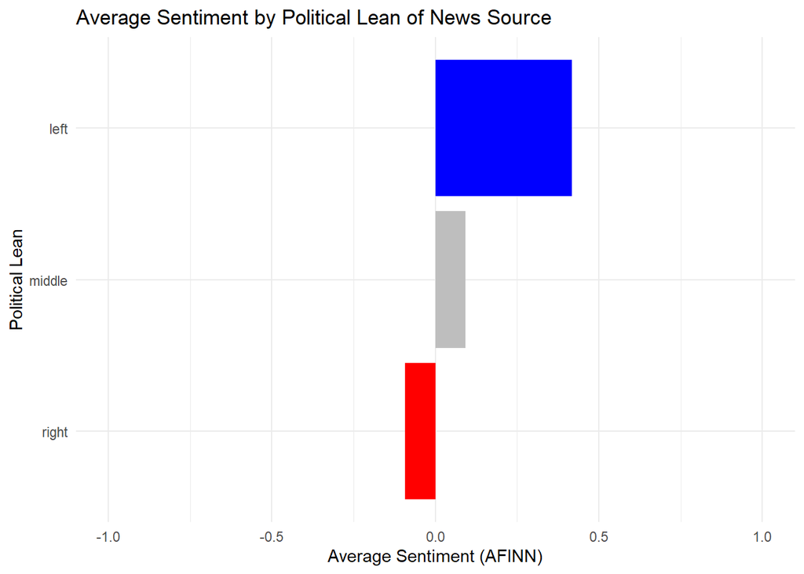

```r
# ggsave("pic1.jpg") # saving the output as jpg

# creating bar graph for data_afinn_lean with legend and sorted by avg
ggplot(data = data_afinn_lean, aes(reorder(political_lean, avg), avg, fill = political_lean)) +
  geom_col() + # bar chart
  coord_flip() + # making it horizontal for legibility
  ggtitle("Average Sentiment by Political Lean of News Source") + # title
  theme_minimal() + # theme
  ylab("Average Sentiment (AFINN)") + # x-axis label (coord_flip is why this is x-axis)
  xlab("Political Lean") + # y-axis label (coord_flip is why this is y-axis)
  scale_y_continuous(limits = c(-1,1)) + # setting scales for x-axis (coord flipped)
  scale_fill_manual(values=c("blue", "gray", "red")) + # setting colors
  theme(legend.position="none") # hiding legend
```

```r
# ggsave("pic2.jpg") # saving the output as jpg
```

Creating new data frames for each lean with afinn lexicon

```r
left_afinn <- filter(data_afinn, political_lean == "left") # filtering data_afinn where political_lean is left
middle_afinn <- filter(data_afinn, political_lean == "middle") # filtering data_afinn where political_lean is left
right_afinn <- filter(data_afinn, political_lean == "right") # filtering data_afinn where political_lean is left
```

T-tests

```r
t.test(left_afinn$value, right_afinn$value) # lowest p-value  # calculating t-test for the left and right columns
```

```
##
##  Welch Two Sample t-test
##
## data:  left_afinn$value and right_afinn$value
## t = 5.4263, df = 1211.8, p-value = 6.944e-08
## alternative hypothesis: true difference in means is not equal to 0
## 95 percent confidence interval:
##  0.3253256 0.6938025
## sample estimates:
##   mean of x   mean of y
##  0.41712707 -0.09243697
```

```r
t.test(left_afinn$value, middle_afinn$value) # low p-value  # calculating t-test for the left and middle columns
```

```
##
##  Welch Two Sample t-test
##
## data:  left_afinn$value and middle_afinn$value
## t = 3.7393, df = 1465.3, p-value = 0.0001916
## alternative hypothesis: true difference in means is not equal to 0
## 95 percent confidence interval:
##  0.1547001 0.4960954
## sample estimates:
##  mean of x  mean of y
## 0.41712707 0.09172932
```

```r
t.test(middle_afinn$value, right_afinn$value) # just above .05  # calculating t-test for the middle and right columns
```

```
##
##  Welch Two Sample t-test
##
## data:  middle_afinn$value and right_afinn$value
## t = 1.8209, df = 1219.5, p-value = 0.06887
## alternative hypothesis: true difference in means is not equal to 0
## 95 percent confidence interval:
##  -0.01426458  0.38259717
## sample estimates:
##   mean of x   mean of y
##  0.09172932 -0.09243697
```

Creating dummy variables for glm (making 3 instead of 2 because of glm)

```r
data_afinn_source$left <- ifelse(data_afinn_source$political_lean == "left", 1, 0) # creating a column in the data_afinn_source data frame named left that is one if the political_lean is left and 0 otherwise
data_afinn_source$right <- ifelse(data_afinn_source$political_lean == "right", 1, 0) # creating a column in the data_afinn_source data frame named right that is one if the political_lean is right and 0 otherwise
data_afinn_source$middle <- ifelse(data_afinn_source$political_lean == "middle", 1, 0) # creating a column in the data_afinn_source data frame named middle that is one if the political_lean is middle and 0 otherwise
```

```r
mod1glm <- glm(left~avg, data = data_afinn_source)
summary(mod1glm) # low p-value # looking at the summary for the logistic regression between left and avg variables
```

```
##
## Call:
## glm(formula = left ~ avg, data = data_afinn_source)
##
## Deviance Residuals:
##     Min       1Q   Median       3Q      Max
## -0.4782  -0.2412  -0.1090   0.3755   0.4032
##
## Coefficients:
##             Estimate Std. Error t value Pr(>|t|)
## (Intercept)   0.1619     0.1289   1.255    0.250
## avg           1.2490     0.4064   3.073    0.018 *
## ---
## Signif. codes:  0 '***' 0.001 '**' 0.01 '*' 0.05 '.' 0.1 ' ' 1
##
## (Dispersion parameter for gaussian family taken to be 0.1216199)
##
##     Null deviance: 2.00000  on 8  degrees of freedom
## Residual deviance: 0.85134  on 7  degrees of freedom
## AIC: 10.317
##
## Number of Fisher Scoring iterations: 2
```

```r
summary(glm(right~avg, data = data_afinn_source)) # barely low p-value # looking at the summary for the logistic regression between right and avg variables
```

```
##
## Call:
## glm(formula = right ~ avg, data = data_afinn_source)
##
## Deviance Residuals:
##      Min        1Q    Median        3Q       Max
## -0.52805  -0.20760  -0.08056   0.18227   0.58665
##
## Coefficients:
##             Estimate Std. Error t value Pr(>|t|)
## (Intercept)   0.4822     0.1489   3.239   0.0143 *
## avg          -1.0841     0.4692  -2.311   0.0541 .
## ---
## Signif. codes:  0 '***' 0.001 '**' 0.01 '*' 0.05 '.' 0.1 ' ' 1
##
## (Dispersion parameter for gaussian family taken to be 0.1620781)
##
##     Null deviance: 2.0000  on 8  degrees of freedom
## Residual deviance: 1.1345  on 7  degrees of freedom
## AIC: 12.902
##
## Number of Fisher Scoring iterations: 2
```

```r
summary(glm(middle~avg, data = data_afinn_source)) # bad p-values # looking at the summary for the logistic regression between middle and avg variables
```

```
##
## Call:
## glm(formula = middle ~ avg, data = data_afinn_source)
##
## Deviance Residuals:
##     Min       1Q   Median       3Q      Max
## -0.4289  -0.3455  -0.2949   0.6371   0.6858
##
## Coefficients:
##             Estimate Std. Error t value Pr(>|t|)
## (Intercept)   0.3560     0.1966   1.810    0.113
## avg          -0.1648     0.6198  -0.266    0.798
##
## (Dispersion parameter for gaussian family taken to be 0.2828556)
##
##     Null deviance: 2.00  on 8  degrees of freedom
## Residual deviance: 1.98  on 7  degrees of freedom
## AIC: 17.914
##
## Number of Fisher Scoring iterations: 2
```

Plotting mod1glm

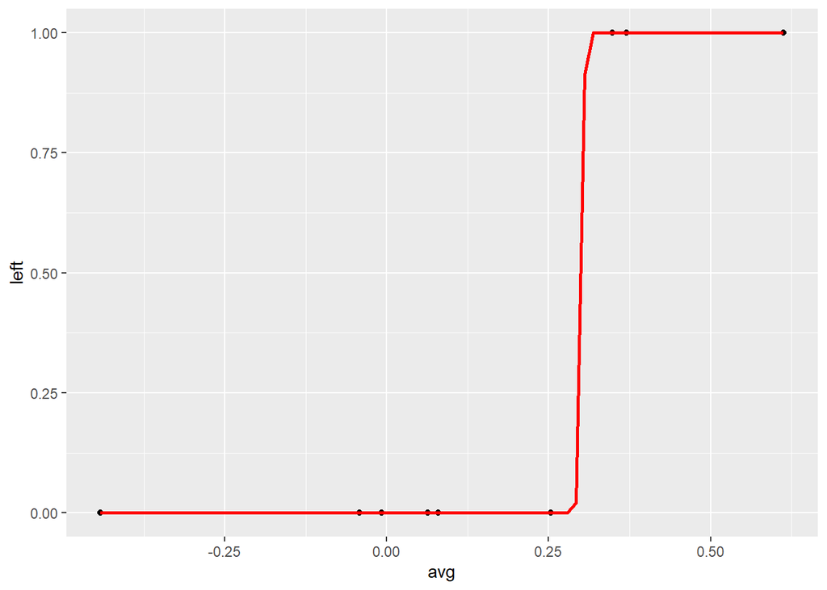

```r
# Creating a scatter plot with a curve for glmmod1
ggplot(data_afinn_source, aes(x = avg, y = left)) +
  geom_point() + # scatter plot
  stat_smooth(method = "glm", color = "red", se = FALSE, method.args = list(family = binomial)) #curve
```

```r
mod1glm_pred <- predict(mod1glm, data_afinn_source)
mod1glm_pred
```

```
##          1          2          3          4          5          6          7
##  0.9273400  0.6245392  0.5967815  0.4781804  0.2611998  0.2411499  0.1522067
##          8          9
##  0.1090107 -0.3904082
```

```r
data_afinn_source$avg
```

```
## [1]  0.612903226  0.370460048  0.348235294  0.253275109  0.079545455
## [6]  0.063492063 -0.007722008 -0.042307692 -0.442176871
```